# Using mechanistic models to assess temporary closure management strategies of octopus fisheries

Sophie Wulfing, Easton White, Ahilya Sudarshan Kadba

2022-09-08

# 1 INTRODUCTION

Mechanistic models in ecology explicitly include species life histories, behavioral, or other mechanisms to describe how a population or community may change over time (André, Haddon, and Pecl 2010; Briggs-Gonzalez et al. 2016). This is in contrast to statistical models that may be focused on correlating a response variable with different covariates and less focus on mechanisms. Mechanistic models are important in situations without existing long-term data, when future conditions may not be similar to the past, and when different scenarios or actions need to be assessed (Crouse, Crowder, and Caswell 1987; Gharouni et al. 2015; Nowlis 2000). Thus, mechanistic models play a critical role in making informed conservation decisions, such as the management of fisheries. Yet, these models are sometimes not used in scenarios that may be helpful, such as data-poor small scale fisheries, because of their perceived complexity.

The ocean environments off the southwest coast of Madagascar are home to a wide variety of marine life, as sand beds, seagrass beds and coral reefs are all prominent biomes in the area. Increased urbanization in the region has led to higher fishing pressure which has in turn led to a decline in fish catch and biomass (Laroche et al. 1997). In fact, Madagascar has been calculated to be among the top countries for potential successful preservation based on the potential economic benefits and success of harvest regulation (MacNeil et al. 2020), especially in the western region of the country (Laroche et al. 1997). 32 million fishers make their livelihood in small-scale fisheries, a subsector in which 90 to 95% of fish is distributed for local consumption. These marine products are a vital source of nutrition for these communities (“HIDDEN HARVEST-The Global Contribution of Capture Fisheries” 2012). In the early 2000’s, however, Madagascar began to move from local, subsistence fishing to selling and exporting catch to export markets (Humber et al. 2006), and there is evidence that up to 75% of all fish caught is now sold to outside entities for export (Baker-Médard 2017).

Marine Protected Areas (MPAs) are regions in the ocean identified as being biologically important and fishing protections are therefore enforced. Before their establishment in Madagascar, governmental bodies had bans on certain types of fishing gear, implemented seasonal fishing regulations, and criminalized the harvest of endangered species. However, these strategies proved ineffective in execution and in their conservation goals (Humber et al. 2006). Both the government and nongovernmental organizations have since pledged to drastically increase the number of regions dedicated as MPAs through temporary fishing closures (Baker-Médard 2017; Cinner et al. 2009; Oliver et al. 2015). One such class of MPAs that are currently being used in Madagascar are temporary closures. Temporary closures have a long history of use and have been seen to successfully rehabilitate stocks (Camp, Poorten, and Walters 2015; Gnanalingam and Hepburn 2015). This method is flexible, logistically simple for fishers and enforcers to understand, and mitigates the financial loss from the fishery that can be seen with permanent closures (Camp, Poorten, and Walters 2015; Gnanalingam and Hepburn 2015; Cohen and Foale 2013; Nowlis 2000; Oliver et al. 2015; Humber et al. 2006). However, they are not always effective in their goal of replenishing stocks and this can depend on a wide range of factors. Ecological considerations about the life history of the target species, allee effects, and changes to community structure and species interactions all play a role in how well the temporary closure will protect the fishery (Russ and Alcala 1998; Gnanalingam and Hepburn 2015; Cohen and Foale 2013; Gilchrist et al. 2020; Grorud-Colvert et al. 2021). Further, the characteristics of the fishery itself has been seen to influence fishery recovery. Fishing method, where the effort will be redistributed to, and fishing activity upon reopening have all been factors in negating the recovery made during the closure Cohen and Foale (2013). Instituting effective temporary closures in octopus fisheries can be difficult due to their short lifespan, high mortality, and sensitivity to environmental conditions (Emery, Hartmann, and Gardner 2016). Lack of field data and difficulty of enforcement has also been a challenge in octopus fisheries, especially in Madagascar (Emery, Hartmann, and Gardner 2016; Benbow et al. 2014). This indicates that a thorough understanding of the life history of *O. Cyanea* and the harvest methods employed by fishers is necessary to enact meaningful fishing restrictions.

Since 2003, when this resource first began to globalize, cephalopods have become one of the largest classes of exports (Humber et al. 2006; Aina 2009; Barnes-Mauthe 2013). This has since added significant fishing pressure to Madagascar’s cephalopod populations and yield from this fishery has decreased in the southwest Andavadoaka region (Humber et al. 2006). Cephalopods are a vital part of many ocean ecosystems and, compared to other fisheries, have a unique life history that can lead to distinct and variable population dynamics. Cephalopods act as both predators and prey in an ecosystem (Rodhouse and Nigmatullin 1996; Santos, Clarke, and Pierce 2001; Vase et al. 2021), situating them in a key role in food webs. They also provide rich nutrition and bioactive compounds to the oceanic microbial community (Catalán et al. 2006; Fitahia et al. 2018; Ibáñez et al. 2019; Van Nieuwenhove, Ratsimbazafy, and Kochzius 2019). Further, their abundance varies drastically with a wide range of ocean conditions including sea surface and bottom temperature, salinity, currents, and sediment type (Catalán et al. 2006; Ibáñez et al. 2019; Van Nieuwenhove, Ratsimbazafy, and Kochzius 2019). Compared to other exploited marine organisms, cephalopods have a short lifespan coupled with a fast reproduction rate and high fecundity. This explains their population’s ability to quickly bounce back when short term MPAs are introduced into their habitat (Benbow et al. 2014; Humber et al. 2006; Katsanevakis and Verriopoulos 2006). However, once fishing resumes, populations suddenly and rapidly decline although in some examples, this could be attributed to heavy fishing pressure in the area right after reopening (Humber et al. 2006). Cephalopods are therefore extremely sensitive to both protection and harvest levels, and understanding how these volatile population dynamics will react to changes in fishing pressure is a key component to effective conservation of this resource.

*Octopus cyanea*, or blue octopus, is the most abundant cephalopod species in the western Indian Ocean and is caught in about 95% of local landings (Humber et al. 2006; Oliver et al. 2015). Like other cephalopod species, very little is known about their life history including natural death rate, larval survivability, and how much time this species remains in each stage of maturity. Further, age is difficult to determine from size alone as they have variable growth rates up to maturity (Raberinary and Benbow 2012; Herwig et al. 2012; Heukelem 1976; Wells and Wells 1970). Size limits have been shown to be the most effective method of conservation for cephalopods in general as it ensures individuals will breed before being harvested (Nowlis 2000; Emery, Hartmann, and Gardner 2016). To protect this species, size limits have been imposed on blue octopus catch in Madagascar, but these regulations are difficult in practice, as blue octopus typically die before size can be assessed (Humber et al. 2006). Further, the relationship between size and maturity stage is not strongly correlated (Raberinary and Benbow 2012) and as a result would be difficult to implement in the field. Therefore, temporary closures have been shown to be a more practical method of blue octopus conservation (Benbow et al. 2014), however this requires a deeper understanding of the characteristics of *Octopus cyanea* in this fishery in order to be properly instituted.

In this paper, we have four goals: 1) we will fit a Levkovitch matrix to the limited available data on *Octopus cyanea* populations in southwestern Madagascar, 2) determine what conservation actions need to be taken, 3) as well as create a theoretical estimation of the species’ life history traits in different stages of its development and 4) determine the frequency and length in which these temporary closures should take place to maximize population health of both the octopus and the local community.

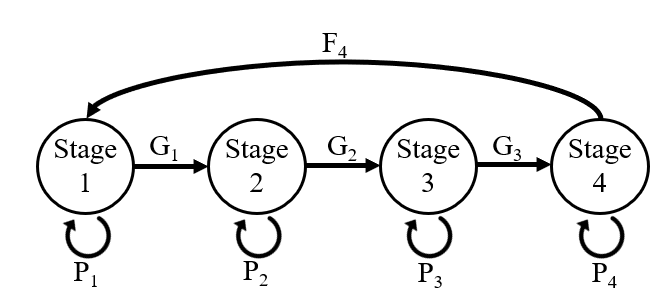

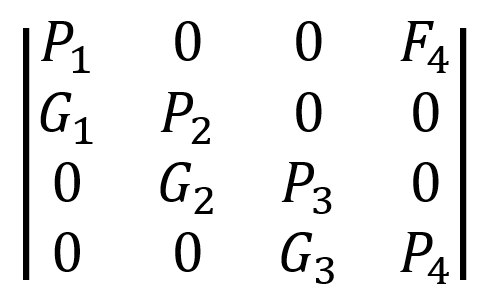

Figure 1.1: A graph representing the life history of *O. Cyanea* and the subsequent Lefkivitch Matrix where i corresponds with each of the stages of maturity. $P_i$ corresponds to probability of surviving and staying within a stage. $G_i$ is the probability of surviving and growing to the next stage. $F_i$ is the reproductive output of stage i.

# 2 METHODS

## 2.1 Data

To inform our model, we used data collected by Raberinary and Benbow (2012) from landings ranging from the villages of Ampasilava in the south to Andragnombala in the north which spans about 30 kilometers of coastline. This study collected landing data from February 2005 to February 2006 through daily surveying fishers as they landed onshore within a two hour window. They recorded octopus weight, weight and length of gonads, sex, and a visual assessment of maturity class. A subsample of octopus were also collected for octopus length, and laboratory assessment of gonads for a confirmation of maturity class. They gathered this data on a total of 3253 octopuses, and for the purposes of this study, we will be modeling from the 1578 females collected. Despite there being no standardization for catch effort being available for this dataset, no other maturity stage study has been conducted on this population of *O. cyanea* and is therefore the best available data to fit a Lefkovitch matrix.

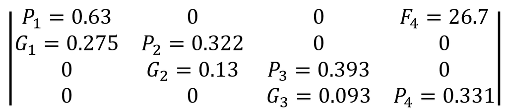

Figure 2.1: Stage-based population matrix calculated using Wood’s quadratic programming method and parameterized using data from Raberinary and Benbow (2012).

## 2.3 Model Analysis

Eigenvalues ($\lambda$) were then calculated from the matrix, which indicate population growth rate (r) as $\lambda$ = $e^r$. Further, future populations can be predicted by multiplying a population vector to incrementally higher powers of our matrix where the power of the matrix corresponds to the time length of the projection.

We performed sensitivity analysis on the population matrix and eigenvalues using the r package popbio (Stubben and Milligan 2007). The result of this analysis indicates how much the dominant eigenvalue will change as a result of perturbations in each parameter of the matrix (Demetrius 1969). Further, as all of the parameters are scaled to a value between 0 and 1 except $F_4$, a unit change in these parameters will have a greater proportional effect on the eigenvalue than $F_4$. To address this, we also conducted elasticity analysis using the popbio package (Stubben and Milligan 2007). Similar to sensitivity analysis, elasticity indicates how heavily the growth rate will respond to a proportional change in each parameter in the matrix (Kroon et al. 1986). This will allow us to identify the groups within this octopus population whose protection will most benefit population growth, essentially creating focus points of conservation. Other life history traits that can be calculated from this matrix are stable stage distribution, reproductive value of each stage, average lifespan, and per-stage survivability.

Finally, we calculated the minimum survivability increase necessary per stage to result in an increase of the overall population. We did this by increasing the $P_i$ and $G_i$ parameters by increasing percentages in each stage i until the overall eigenvalue ($\lambda$) became greater than one.

## 2.4 Management Scenarios

In order to determine optimal conservation strategies, we altered the survivability of *O. cyanea* by different rates from 0-10% survival increase of the species. Then, we simulated different closure scenarios for each survival increase, increasing the number of months between closures. We then took the weighted average of the growth rates of the closed and open fishing scenarios for the hypothetical population and analyzed if this resulted in a stable population (i.e if the resulting rate of increase was positive). Pareto analysis was then conducted on these different scenarios in order to analyze all combinations of conservation strategies that result in stable *O. cyanea* populations.

# 3 RESULTS

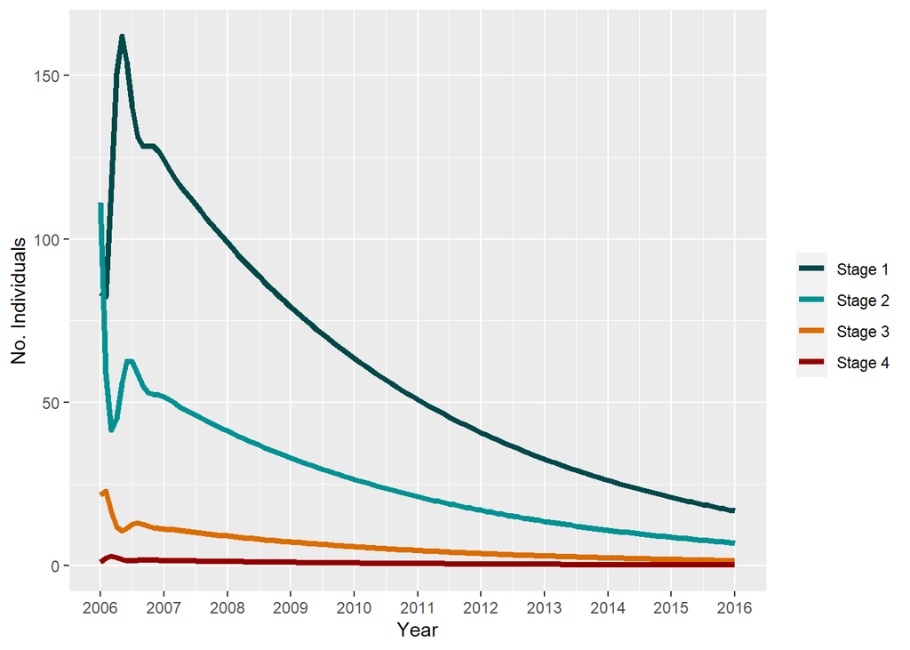

Figure 3.1: Ten-year projection of *O. cyanea* population based off of our calculated Lefkovitch matrix.

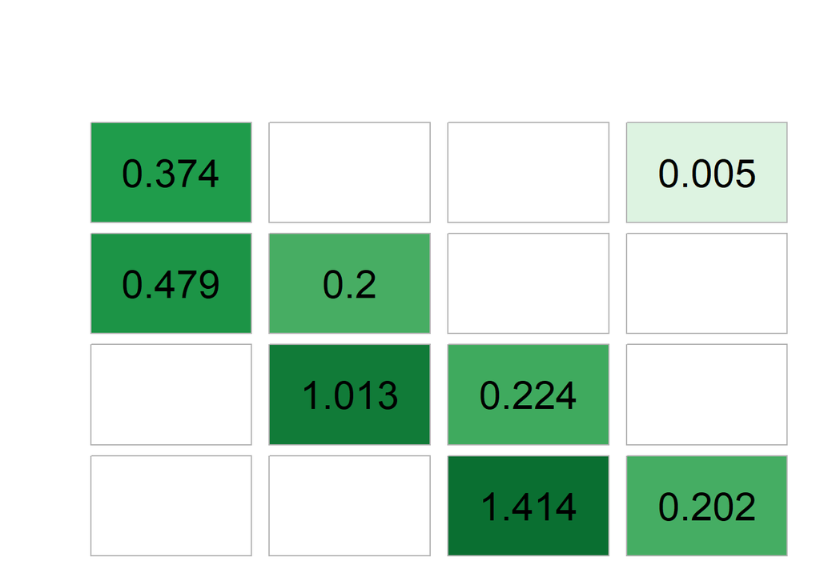

Figure 3.2: Sensitivity analysis of our matrix model - the change in the eigenvalue ($\lambda$) as a result of a unit change of each parameter in the model.

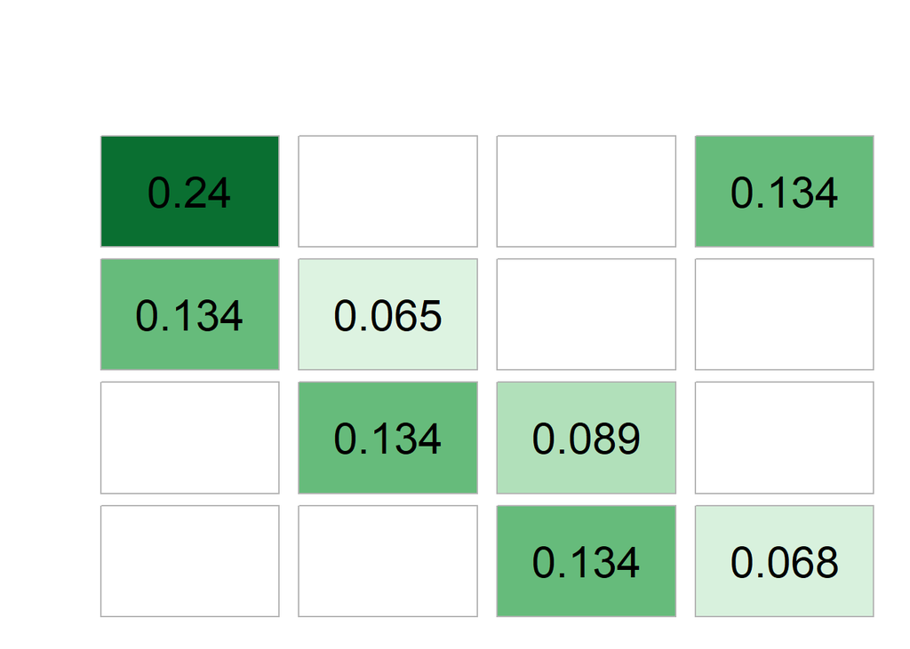

Figure 3.3: Elasticity analysis of our matrix model - the change in the eigenvalue ($\lambda$) as a result of a proportional change of each paramter in the model.

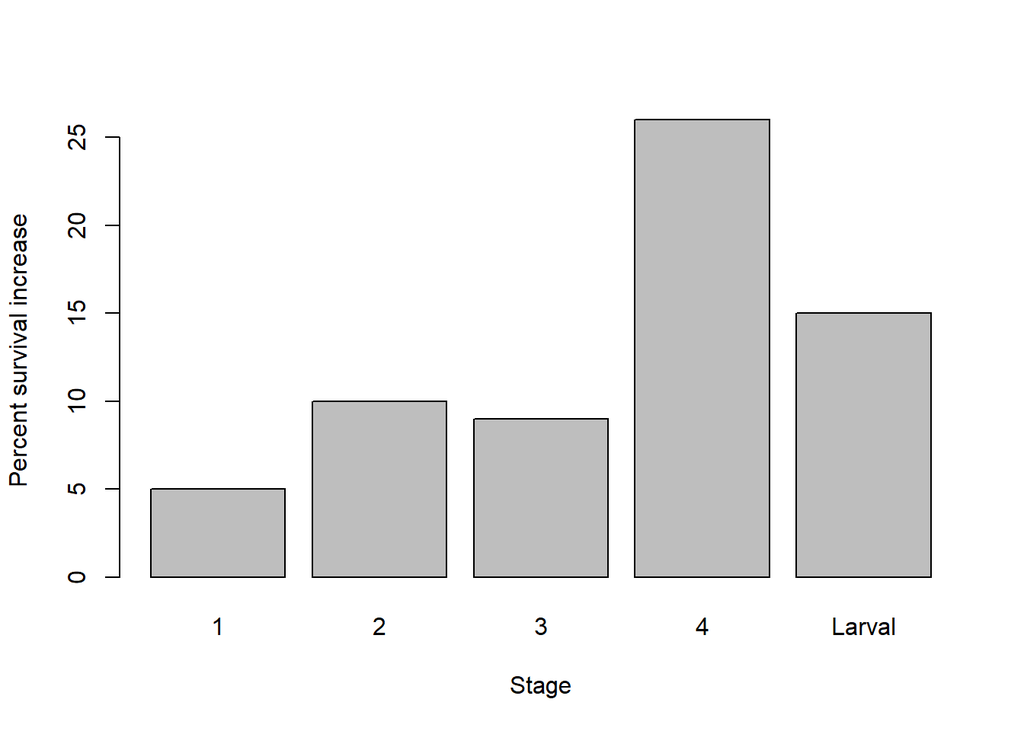

Figure 3.4: Minimum % per-stage survivability change needed to create population increase.

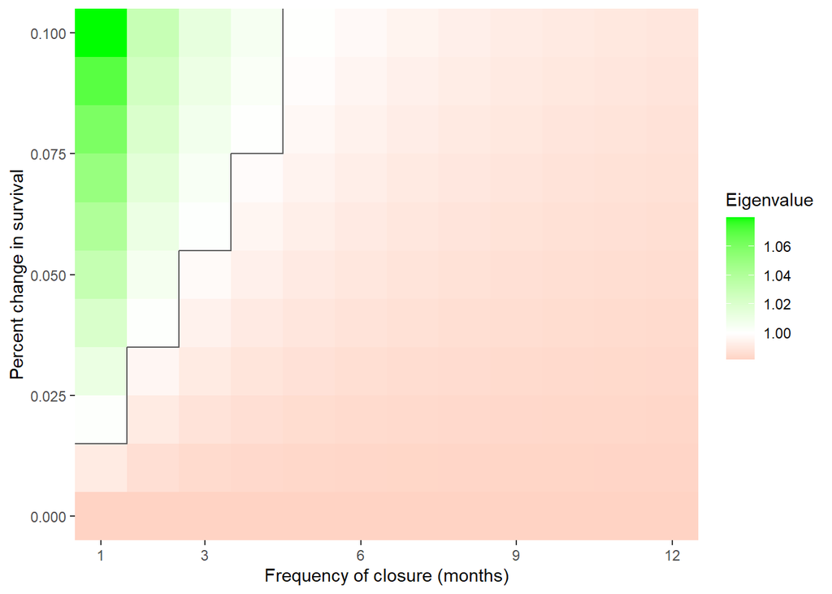

Figure 3.5: Paretto analysis of different management scenarios. The paretto front is represented by the black line. Green and white squares indicate theoretically successful management scenarios where red refers to the strategies that will not result in overall population growth. Frequency of closures refers to the number of months between a closure (i.e. 1 is closing every month and 12 being a closure for one month per year).

# 4 DISCUSSION

Elasticity analysis shows that targeting of both the growth and reproductive parameters would have equal effect on the overall population growth, with the most influential parameter being the survival of stage 1 individuals. The sensitivity and elasticity analysis could potentially have conservation implications as they indicate which stages will have the greatest effect on the population if they are targeted for preservation practices. Previous research has indicated that catch size limits are very effective in preserving stocks of species with rapid growth and high death rates, but this is only if individuals do not enter the fishery until they have reached maturity (Nowlis 2000). However, as the fishing method employed by the local people does not discriminate based on stage, this is not an applicable suggestion for conservation practices. For this reason, even though our analysis of different stage survivabilities indicates that conserving immature individuals would be an effective tool for fostering population growth, this is not a realistic management practice in this fishery.

When implemented deliberately, establishing periodic closures is an effective and commonly-used strategy when implementing sustainable fishing practices (Humber et al. 2006; Oliver et al. 2015). As Madagascar has been committed to protecting its marine natural resources through increasing the number of marine parks, this study serves to highlight some of the available strategies to make population predictions and conservation strategies with limited data sources (Westlund 2017). Implementing fishing restrictions without regard for cultural practices can undermine cultural practices and in turn be detrimental to both the people and fishery, and halts the dissemination of traditional ecological knowledge (Okafor-Yarwood et al. 2022). For this reason, both the Madagascar government and scientific community has found a new emphasis on studying the complex social structures within the community in question in order to more effectively preserve resources along with peoples’ livelihoods (Baker-Médard, Gantt, and White 2021; Billé and Mermet 2002). This has been shown to increase participation in conservation practices, therefore making them more effective.

The mechanistic methods utilized in this study allowed us to gain a baseline understanding of the growthrate and mortality of this population despite the limited data used to parameterize the model. Limitations of this study include the data collection process as even though daily collections occurred daily within a two-hour window, catch was not standardized by effort and therefore there could be catch fluctuations between months that are not captured in the data. However, we can be confident that the catch represented is an accurate representation of the ratio of octopus in each stage. Further, matrix population models will converge or diverge based on their dominant eigenvalue, regardless of the initial population inputted in the model. Therefore, we can still conclude that the population at this time was in an overall decline, despite not knowing the exact number of individuals in this population. Another shortcoming of this study is that the only available stage data for this species and region was collected in 2006, and the community of southwest Madagascar has implemented several strategies since that time to improve the sustainability of their fish stocks in the region (Humber et al. 2006; Raberinary and Benbow 2012). Due to the time of data collection, this study does not reflect the current status of *Octopus cyanea*, but outlines the underlying population dynamics and serves to indicate the need for a more current assessment of *O. cyanea* stocks in the region. Finally, as we are using a Lefkovitch matrix to simulate population fluctuations, these models inherently make simplifying assumptions about the biology of the study species. For example, these models assume that all individuals within a stage are subject to the same growth and mortality rates. As this study uses data collected from a large geographic range (Raberinary and Benbow 2012), different individuals nesting in different regions may be subject to different selective pressures. Despite these limitations, the data provided is the best data available for fitting a Lefkovitch matrix to this species.

As cephalopod species tend to react faster to easing fishing pressure, a study of other fished species in the region is necessary to understand the effectiveness of MPAs. This study also highlights the need for further research into the life history patterns of *Octopus cyanea*. Specifically, studies on the natural mortality rate of this species, both in the larval and benthic stages, could better inform both our model and the greater understanding of how populations of this species grow. Further, a more contemporary study on the status of the octopus fishery of southwest Madagascar will paint a more accurate picture of how this population is faring under the current fishing pressure. These studies can also be used to build off of this one as more in depth data collection could be used to add spatial connectivity to our model, where we then can evaluate the accuracy of the assumption that every individual within a stage is subject to the same selective pressure. Finally, as the people of southwestern Madagascar are actively taking steps to preserve the health of their fisheries, we hope that studies such as these can serve to facilitate informed decision making when choosing how and when to impose fishing restrictions.

Aina, Tantely Andriamaharo Ny. 2009. “MANAGEMENT OF OCTOPUS FISHERY OFF SOUTH WEST MADAGASCAR.” *United Nations University Fisheries Training Programme, Iceland [Final Project*, 39. http://www.unuftp.is/static/fellows/document/tantely09prf.pdf.

André, Jessica, Malcolm Haddon, and Gretta T. Pecl. 2010. “Modelling Climate-Change-Induced Nonlinear Thresholds in Cephalopod Population Dynamics: CLIMATE CHANGE AND OCTOPUS POPULATION DYNAMIC.” *Global Change Biology* 16 (10): 2866–75. https://doi.org/10.1111/j.1365-2486.2010.02223.x.

Baker-Médard, Merrill. 2017. “Gendering Marine Conservation: The Politics of Marine Protected Areas and Fisheries Access.” *Society & Natural Resources* 30 (6): 723–37. https://doi.org/10.1080/08941920.2016.1257078.

Baker-Médard, Merrill, Courtney Gantt, and Easton R. White. 2021. “Classed Conservation: Socio-Economic Drivers of Participation in Marine Resource Management.” *Environmental Science & Policy* 124 (October): 156–62. https://doi.org/10.1016/j.envsci.2021.06.007.

Barnes-Mauthe, Michele. 2013. “The Total Economic Value of Small-Scale Fisheries with a Characterization of Post-Landing Trends: An Application in Madagascar with Global Relevance.” *Fisheries Research*, 11.

Benbow, S, F Humber, Ta Oliver, Kll Oleson, D Raberinary, M Nadon, H Ratsimbazafy, and A Harris. 2014. “Lessons Learnt from Experimental Temporary Octopus Fishing Closures in South-West Madagascar: Benefits of Concurrent Closures.” *African Journal of Marine Science* 36 (1): 31–37. https://doi.org/10.2989/1814232X.2014.893256.

Billé, Raphaël, and Laurent Mermet. 2002. “Integrated Coastal Management at the Regional Level: Lessons from Toliary, Madagascar.” *Ocean & Coastal Management* 45 (1): 41–58. https://doi.org/10.1016/S0964-5691(02)00048-0.

Briggs-Gonzalez, Venetia, Christophe Bonenfant, Mathieu Basille, Michael Cherkiss, Jeff Beauchamp, and Frank Mazzotti. 2016. “Life Histories and Conservation of Long‐lived Reptiles, an Illustration with the American Crocodile (Crocodylus Acutus).” *Journal of Animal Ecology* 1365 (2656.12723): 12.

Camp, Edward V., Brett T. van Poorten, and Carl J. Walters. 2015. “Evaluating Short Openings as a Management Tool to Maximize Catch-Related Utility in Catch-and-Release Fisheries.” *North American Journal of Fisheries Management* 35 (6): 1106–20. https://doi.org/10.1080/02755947.2015.1083495.

Caswell, H. 2001. *Matrix Population Models: Construction, Analysis, and Interpretation*. Matrix Population Models: Construction, Analysis, and Interpretation. Sinauer Associates. https://books.google.com/books?id=CPsTAQAAIAAJ.

Catalán, I. A., M. T. Jiménez, J. I. Alconchel, L. Prieto, and J. L. Muñoz. 2006. “Spatial and Temporal Changes of Coastal Demersal Assemblages in the Gulf of Cadiz (SW Spain) in Relation to Environmental Conditions.” *Deep Sea Research Part II: Topical Studies in Oceanography* 53 (11-13): 1402–19. https://doi.org/10.1016/j.dsr2.2006.04.005.

Cinner, Joshua E., Andrew Wamukota, Herilala Randriamahazo, and Ando Rabearisoa. 2009. “Toward Institutions for Community-Based Management of Inshore Marine Resources in the Western Indian Ocean.” *Marine Policy* 33 (3): 489–96. https://doi.org/10.1016/j.marpol.2008.11.001.

Cohen, Philippa J., and Simon J. Foale. 2013. “Sustaining Small-Scale Fisheries with Periodically Harvested Marine Reserves.” *Marine Policy* 37 (January): 278–87. https://doi.org/10.1016/j.marpol.2012.05.010.

Crouse, Deborah T., Larry B. Crowder, and Hal Caswell. 1987. “A Stage-Based Population Model for Loggerhead Sea Turtles and Implications for Conservation.” *Ecology* 68 (5): 1412–23. https://doi.org/10.2307/1939225.

Demetrius, Lloyd. 1969. “The Sensitivity of Population Growth Rate to Pertubations in the Life Cycle Components.” *Mathematical Biosciences* 4 (1-2): 129–36. https://doi.org/10.1016/0025-5564(69)90009-1.

Emery, Timothy J., Klaas Hartmann, and Caleb Gardner. 2016. “Management Issues and Options for Small Scale Holobenthic Octopus Fisheries.” *Ocean & Coastal Management* 120 (February): 180–88. https://doi.org/10.1016/j.ocecoaman.2015.12.004.

Fitahia, Edda Miray, Mikael Croyal, Christian E. Raheriniaina, Véronique Ferchaud-Roucher, and Hassan Nazih. 2018. “High-Resolution Mass Spectrometry Unravels a Broad Range of Bioactive Lipid Species in Octopus Cyanea and Loligo Sp. By-Products from Southwestern Madagascar.” *Waste and Biomass Valorization* 9 (10): 1787–93. https://doi.org/10.1007/s12649-017-9933-x.

Gharouni, A, Ma Barbeau, A Locke, L Wang, and J Watmough. 2015. “Sensitivity of Invasion Speed to Dispersal and Demography: An Application of Spreading Speed Theory to the Green Crab Invasion on the Northwest Atlantic Coast.” *Marine Ecology Progress Series* 541 (December): 135–50. https://doi.org/10.3354/meps11508.

Gilchrist, Hannah, Steve Rocliffe, Lucy G. Anderson, and Charlotte L. A. Gough. 2020. “Reef Fish Biomass Recovery Within Community-Managed No Take Zones.” *Ocean & Coastal Management* 192 (July): 105210. https://doi.org/10.1016/j.ocecoaman.2020.105210.

Gnanalingam, Gaya, and Chris Hepburn. 2015. “Flexibility in Temporary Fisheries Closure Legislation Is Required to Maximise Success.” *Marine Policy* 61 (November): 39–45. https://doi.org/10.1016/j.marpol.2015.06.033.

Grorud-Colvert, Kirsten, Jenna Sullivan-Stack, Callum Roberts, Vanessa Constant, Barbara Horta e Costa, Elizabeth P. Pike, Naomi Kingston, et al. 2021. “The MPA Guide: A Framework to Achieve Global Goals for the Ocean.” *Science* 373 (6560): eabf0861. https://doi.org/10.1126/science.abf0861.

Guard, Martin. 2009. “Biology and Fisheries Status of Octopus in the Western Indian Ocean and the Suitability for Marine Stewardship Council Certification.” e United Nations Environment Programme.

Herwig, Jade N., Martial Depczynski, John D. Roberts, Jayson M. Semmens, Monica Gagliano, and Andrew J. Heyward. 2012. “Using Age-Based Life History Data to Investigate the Life Cycle and Vulnerability of Octopus Cyanea.” Edited by Sebastian C. A. Ferse. *PLoS ONE* 7 (8): e43679. https://doi.org/10.1371/journal.pone.0043679.

Heukelem, William F Van. 1976. “Growth, Bioenergetics, and Life-Span of Octopus Cyanea and Octopus Maya.” *A Dissertation Submitted to the Graduate Division of the University of Hawaii in Partial Fulfillment of the Requirements for the Degree of Doctor of Philosophy in Zoology*, 232.

“HIDDEN HARVEST-The Global Contribution of Capture Fisheries.” 2012. The World Bank. https://documents1.worldbank.org/curated/en/515701468152718292/pdf/664690ESW0P1210120HiddenHarvest0web.pdf.

Hiddink, J. G., T. Hutton, S. Jennings, and M. J. Kaiser. 2006. “Predicting the Effects of Area Closures and Fishing Effort Restrictions on the Production, Biomass, and Species Richness of Benthic Invertebrate Communities.” *ICES Journal of Marine Science* 63 (5): 822–30. https://doi.org/10.1016/j.icesjms.2006.02.006.

Humber, F., A. Harris, D. Raberinary, and M. Nadon. 2006. “Seasonal Closures of No-Take Zones to Promote A Sustainable Fishery for Octopus Cyanea (Gray) in South West Madagascar.” Blue Ventures Conservation Report. https://blueventures.org/publications/seasonal-closures-of-no-take-zones-to-promote-a-sustainable-fishery-for-octopus-cyanea-gray-in-south-west-madagascar/.

Ibáñez, Christian M., Heather E. Braid, Sergio A. Carrasco, David A. López‐Córdova, Gabriela Torretti, and Patricio A. Camus. 2019. “Zoogeographic Patterns of Pelagic Oceanic Cephalopods Along the Eastern Pacific Ocean.” *Journal of Biogeography* 46 (6): 1260–73. https://doi.org/10.1111/jbi.13588.

Katsanevakis, Stelios, and George Verriopoulos. 2006. “Seasonal Population Dynamics of Octopus Vulgaris in the Eastern Mediterranean.” *ICES Journal of Marine Science* 63 (1): 151–60. https://doi.org/10.1016/j.icesjms.2005.07.004.

Kroon, Hans de, Anton Plaisier, Jan van Groenendael, and Hal Caswell. 1986. “Elasticity: The Relative Contribution of Demographic Parameters to Population Growth Rate.” *Ecology* 67 (5): 1427–31.

Laroche, J., J. Razanoelisoa, E. Fauroux, and M. W. Rabenevanana. 1997. “The Reef Fisheries Surrounding the South‐west Coastal Cities of Madagascar.” *Fisheries Management and Ecology* 4 (4): 285–99. https://doi.org/10.1046/j.1365-2400.1997.00051.x.

Leslie, P H. 1945. “On the Use of Matrices in Certain Population Mathematics,” 31.

MacNeil, M. Aaron, Demian D. Chapman, Michelle Heupel, Colin A. Simpfendorfer, Michael Heithaus, Mark Meekan, Euan Harvey, et al. 2020. “Global Status and Conservation Potential of Reef Sharks.” *Nature* 583 (7818): 801–6. https://doi.org/10.1038/s41586-020-2519-y.

Nowlis, Joshua Sladek. 2000. “Short- and Long-Term Effects of Three Fishery-Management Tools on Depleted Fisheries.” *BULLETIN OF MARINE SCIENCE* 66 (3): 12.

Okafor-Yarwood, Ifesinachi, Nelly I. Kadagi, Dyhia Belhabib, and Edward H. Allison. 2022. “Survival of the Richest, Not the Fittest: How Attempts to Improve Governance Impact African Small-Scale Marine Fisheries.” *Marine Policy* 135 (January): 104847. https://doi.org/10.1016/j.marpol.2021.104847.

Oliver, Thomas A., Kirsten L. L. Oleson, Hajanaina Ratsimbazafy, Daniel Raberinary, Sophie Benbow, and Alasdair Harris. 2015. “Positive Catch & Economic Benefits of Periodic Octopus Fishery Closures: Do Effective, Narrowly Targeted Actions ‘Catalyze’ Broader Management?” Edited by Dennis M. Higgs. *PLOS ONE* 10 (6): e0129075. https://doi.org/10.1371/journal.pone.0129075.

Raberinary, D., and S. Benbow. 2012. “The Reproductive Cycle of Octopus Cyanea in Southwest Madagascar and Implications for Fisheries Management.” *Fisheries Research* 125-126 (August): 190–97. https://doi.org/10.1016/j.fishres.2012.02.025.

Rodhouse, P. G., and M. Nigmatullin. 1996. “Role as Consumers.” *Royal Society Publishing*, 20. https://doi.org/https://doi.org/10.1098/rstb.1996.0090.

Russ, G. R., and A. C. Alcala. 1998. “Natural Fishing Experiments in Marine Reserves 1983-1993: Community and Trophic Responses.” *Coral Reefs* 17 (4): 383–97. https://doi.org/10.1007/s003380050144.

Santos, M. B, M. R Clarke, and G. J Pierce. 2001. “Assessing the Importance of Cephalopods in the Diets of Marine Mammals and Other Top Predators: Problems and Solutions.” *Fisheries Research* 52 (1-2): 121–39. https://doi.org/10.1016/S0165-7836(01)00236-3.

Stubben, Chris J., and Brook G. Milligan. 2007. “Estimating and Analyzing Demographic Models Using the Popbio Package in r.” *Journal of Statistical Software* 22 (11).

Turlach, Berwin A., and Andreas Weingessel. 2019. *Quadprog: Functions to Solve Quadratic Programming Problems*. https://CRAN.R-project.org/package=quadprog.

Van Nieuwenhove, Annelore Hilde M., Hajaniaina Andrianavalonarivo Ratsimbazafy, and Marc Kochzius. 2019. “Cryptic Diversity and Limited Connectivity in Octopuses: Recommendations for Fisheries Management.” Edited by Giacomo Bernardi. *PLOS ONE* 14 (5): e0214748. https://doi.org/10.1371/journal.pone.0214748.

Vase, Vinaya Kumar, Mohammed K. Koya, Gyanaranjan Dash, Swatipriyankasen Dash, K. R. Sreenath, D. Divu, Rajan Kumar, et al. 2021. “Acetes as a Keystone Species in the Fishery and Trophic Ecosystem Along Northeastern Arabian Sea.” *Thalassas: An International Journal of Marine Sciences* 37 (1): 367–77. https://doi.org/10.1007/s41208-020-00276-y.

Wells, M. J., and J. Wells. 1970. “Observations on the Feeding, Growth Rate and Habits of Newly Settled *Octopus Cyanea*.” *Journal of Zoology* 161 (1): 65–74. https://doi.org/10.1111/j.1469-7998.1970.tb02170.x.

Westlund, Lena, ed. 2017. *Marine Protected Areas: Interactions with Fishery Livelihoods and Food Security*. Rome: Food; Agriculture Organization of the United Nations.